# Análisis de Redes Sociales

Rafael Leon, Alejandro Vasquez, Oliversinn Mazariegos

17 de Octubre de 2018

# Problema

Se quieren extraer los datos realcionados con el trafico en la ciudad de Guatemala. Utilizando Twitter. Se utilizará la biblioteca twitteR para realizar la extracción de los datos. Esta interfaz no se comparte en este Rmd. Para proteger las credenciales del API de Twitter. Se estará sourcing a otro documento adjunto llamado *“tweetSweeper.R”*.

## Paso 1 Extraccion de datos de twitter

Se utilizará la función vigilante para extraer tweets relacionados a tráficoGT utilizando un vector de términos con un máximo de 1000 tweets por término por las limitaciones del API de twitter.

```r
tweetDF <- read.csv("GeneralSweep.csv", encoding="UTF-8")
txt <- iconv(tweetDF$text, to="ASCII//TRANSLIT")

#Se le alimenta el vector de cada data frame con los tweets a esta linea para generar diferentes wordclouds
corpus <- Corpus(VectorSource(txt))
```

## Paso 2 Preprocesamiento de los tweets.

Para la limpieza de datos realizaremos los siguientes pasos.

- Pasar todo a minusculas.
- Remover los simbolos de puntuacion.
- Remover los numeros.
- Remover los espacios en blanco.
- Remover los StopWords

```r
tweets_cl <- corpus %>%
  tm_map(tolower) %>%
  tm_map(stripWhitespace) %>%
  tm_map(removePunctuation) %>%
  tm_map(removeWords, c(stopwords("spanish"))) %>%
  tm_map(removeNumbers) %>%
  tm_map(stripWhitespace)
```

## Paso 3 Análisis exploratorio de los datos

Se realizó un análisis exploratorio de los tweets para obtener insights interesantes sobre el tráfico en la ciudad de guatemala.

### Document Term Matrix

La matriz de terminos nos ayudara a obtener una lista de cada palabra por separado.

```r
dtm <-  DocumentTermMatrix(tweets_cl)
dtm2 <- as.matrix(dtm)
```

### WordCloud e Histograma

Con la matriz de terminos realizada, representemos con una nube de palabras las palabras que mas se repiten y veremos con un grafico de barras la frecuencia de estas mismas.

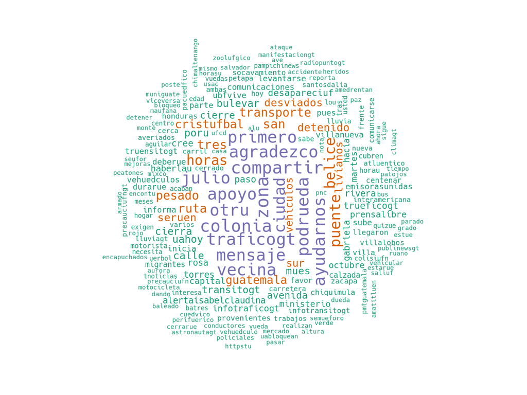

```r
freq_word = colSums(dtm2)
freq_word = sort(freq_word, decreasing = T)
words = names(freq_word)

#plot
wordcloud(words[1:200], freq_word[1:200], random.order = F, colors = brewer.pal(8,'Dark2'))
```

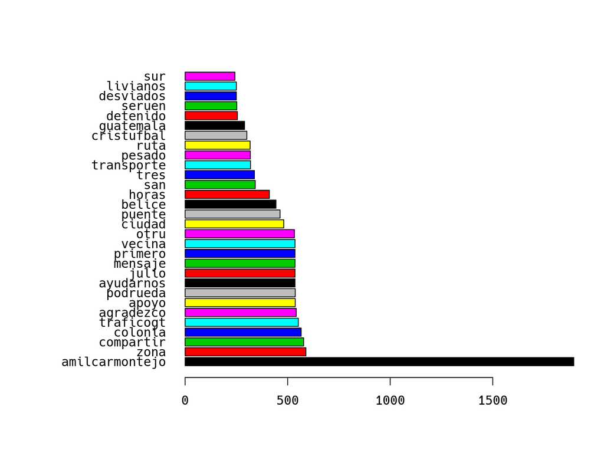

```r
#histogram
freq_matrix = as.matrix(freq_word)
colnames(freq_matrix) = 'n'
cuantos = freq_matrix
freq_matrix = c(row.names(freq_matrix),cuantos)
par(mar=c(5,12,4,2))
barplot(head(freq_word,30), horiz = T, las = 1, col = c(1:30))
```

Amilcar Montejo aparece referenciado muchas veces ya que es la persona responsable de los reportes de tránsito en guatemala. Aparte de eso se ven palabras clave como:

- Zona
- Colonia
- Belice (Por el puente)
- Pesado
- Livianos
- Carril

Algo interesante de notar es la presencia de palabras como *migrantes*, *honduras*. Estos son temas que afectaron al tráfico esta ultima semana debido a la migración masiva de hondureños que estuvieron albergados en **La Casa del Migrante** en la Z1 capitalina. Además de las personas que transitaron por las carreteras de la república de Guatemala, en camino a la frontera mexicana.

Se considera que un análisis de unigramas no es suficiente para obtener contexto de la naturaleza de los tweets entonces como siguiente paso se analizarán bigramas y trigramas

### Bigramas y Trigramas

Se utilizó RWeka para realizar bigramas y trigramas

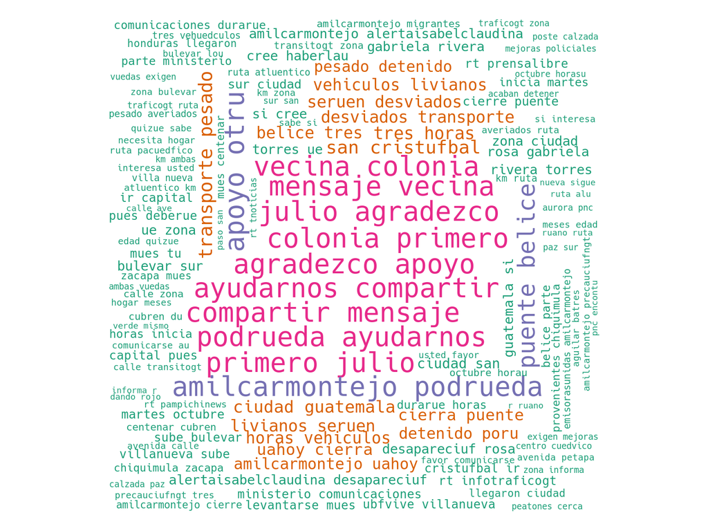

```r
#Funciones para hacer bi y trigramas

BigramTokenizer <- function(x) {RWeka::NGramTokenizer(x, RWeka::Weka_control(min=2, max=2))}
ThreegramTokenizer <- function(x) {RWeka::NGramTokenizer(x, RWeka::Weka_control(min=3, max=3))}


## Bigramas

tweets_cl2 <- VCorpus(VectorSource(tweets_cl))

bigram <- TermDocumentMatrix(tweets_cl2, control = list(tokenize = BigramTokenizer))

m <- as.matrix(bigram)

freq_word = rowSums(m)
freq_word = sort(freq_word, decreasing = T)
words = names(freq_word)

#plot
wordcloud(words[1:200], freq_word[1:200], random.order = F, colors = brewer.pal(8,'Dark2'))
```

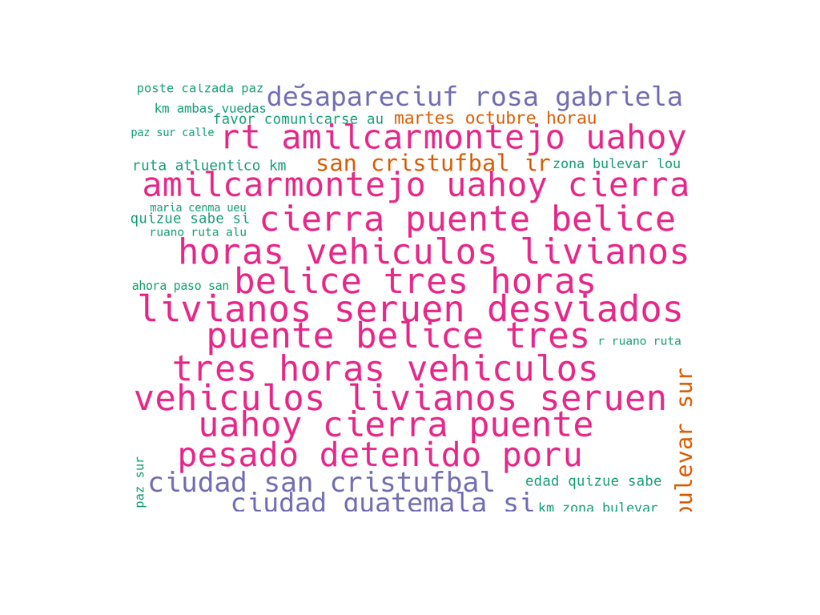

```r
## Trigramas

trigram <- TermDocumentMatrix(tweets_cl2, control = list(tokenize = ThreegramTokenizer))

m <- as.matrix(trigram)
freq_word = rowSums(m)
freq_word = sort(freq_word, decreasing = T)
words = names(freq_word)

wordcloud(words[1:200], freq_word[1:200], random.order = F, colors = brewer.pal(8,'Dark2'))
```

Con la información de bigramas y trigramas se obtuvieron los siguientes insights:

- Ocurrió algo en el puente de belice que cerró el puente por varias horas. Investigar noticias que hablen del tema.
- El tráfico en ciudad san cristobal es un tema importante por lo que se debería revisar que lo causa.
- Las noticias de tráfico afuera de la ciudad de guatemala parecen tener menos importancia que las dentro de la ciudad.
- Se debe investigar que causa que los transportes pesados sean tan importantes para el incremento del tráfico. También se podría investigar si solo fue un evento o si ocurrió varias veces durante la semana.
- Los reportes de tráfico parecen venir de personas en colonias y tratando de conseguir ayuda con frases como: **agradezco su apoyo** dirigidas a Amilcar Montejo. Para la solución de los problemas de tránsito

## Conclusiones

- Los eventos más importantes de la semana que afectaron el tráfico fueron el cierre del puente de belice, la migración hondureña y desperfectos mecánicos de transporte pesado.
- Se puede analizar el sentimiento de los mensajes para determinar la intención de las personas al twittearle a *#transitogt* y a *#traficogt*.
- Se puede observar que prensaibre y otros medios se comunican con los hashtags. Por lo que se podrían hacer análisis de redes sociales para determinar que otros actores están involucrados en estos tweets.